# A2 Relative Prevalence of QRP

Gerko Vink

# Packages used

For this document we use the following packages

```r
library(dplyr)    # Data manipulation
library(mice)     # Data imputation
library(magrittr) # Pipes
library(purrr)    # Functional programming
library(haven)    # Import data
library(DT)       # Interactive tables
library(ggplot2)  # Plotting device
library(reshape2) # Data shaping
library(labelled) # Advanced labelling
```

# Load the data

```r
load(file = "../Workspaces/3. Data imputation.Rdata")
load(file = "../Workspaces/2. Data inspection.Rdata")
```

# QRP with `Not Applicable`’s

First, we create an indicator for all QRP

```r
QRP_set <- names(raw_data[86:107])[-c(1, 2, 4, 6, 9, 12, 15, 16, 17, 19, 21 )]
```

## Tables and plots

### Overall

```r
mice::complete(imp, 1) %>% #QRP has no missings -so use 1st imputed set
  select(all_of(QRP_set)) %>%
  sapply(table)
```

```
##    RP3  RP5  RP7  RP8 RP10 RP11 RP13 RP14 RP18 RP20 RP22
## 0  826 1091  592 1221  343  158  829  576 2702  746  337
## 1 1678 1709 3408 4904 2695 5213 1571 3758 1980 2040 2198
## 2 2402 2289 1959  565 2694 1204 1949 1894  803 2192 2070
## 3  612  575  386   55  557  136  839  285  275  504  718
## 4  413  292  198   23  264   60  755  123  332  299  581
## 5  424  369  137   21  164   29  609   62  344  314  491
## 6  259  302   84   12   73    8  198   62  216  403  225
## 7  199  186   49   12   23    5   63   53  161  315  193
```

Zero indicates not applicable

Then we calculate the proportional table

```r
p_tab <- function(x){prop.table(table(x)) %>% round(3)}
mice::complete(imp, 1) %>% #QRP has no missings -so use 1st imputed set
  select(all_of(QRP_set)) %>%
  sapply(p_tab) %>%
  round(3)
```

```
##     RP3   RP5   RP7   RP8  RP10  RP11  RP13  RP14  RP18  RP20  RP22
## 0 0.121 0.160 0.087 0.179 0.050 0.023 0.122 0.085 0.397 0.109 0.049
## 1 0.246 0.251 0.500 0.720 0.396 0.765 0.231 0.552 0.291 0.299 0.323
## 2 0.353 0.336 0.288 0.083 0.395 0.177 0.286 0.278 0.118 0.322 0.304
## 3 0.090 0.084 0.057 0.008 0.082 0.020 0.123 0.042 0.040 0.074 0.105
## 4 0.061 0.043 0.029 0.003 0.039 0.009 0.111 0.018 0.049 0.044 0.085
## 5 0.062 0.054 0.020 0.003 0.024 0.004 0.089 0.009 0.050 0.046 0.072
## 6 0.038 0.044 0.012 0.002 0.011 0.001 0.029 0.009 0.032 0.059 0.033
## 7 0.029 0.027 0.007 0.002 0.003 0.001 0.009 0.008 0.024 0.046 0.028
```

Next, we create the stacked barplot.

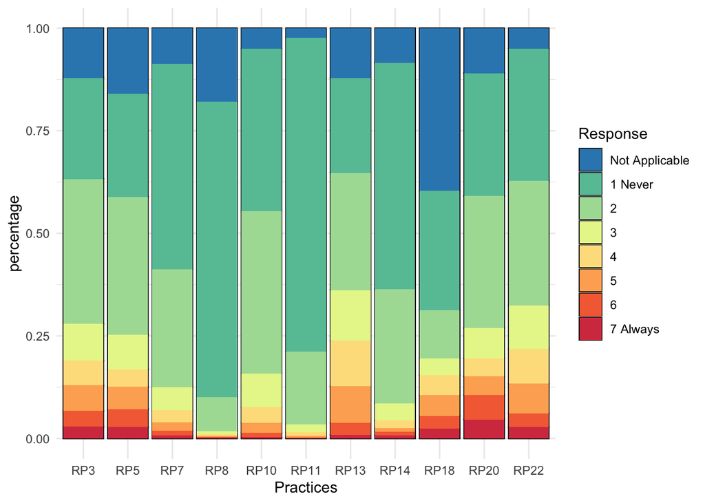

```r
mice::complete(imp, 1) %>% #QRP has no missings -so use 1st imputed set
  select(all_of(QRP_set)) %>%
  sapply(table) %>%
  melt(varnames = c("Response", "Practices")) %>%
  mutate(Response = factor(Response),
         percentage = value / (sum(value)/11),
         Response = recode(Response, `0` = "Not Applicable", `1` = "1 Never", `7` = "7 Always")) %>%
  ggplot(aes(x = Practices, y = percentage, fill = Response)) +
  geom_bar(stat = 'identity', position = "stack", colour="black") +
  geom_col(position = position_stack(reverse = FALSE)) +
  scale_fill_brewer(palette = "Spectral", direction = -1) +
  theme_minimal()
```

### By Disciplinary Field

First, we grab the info from `D2`

```r
raw_data$D2 %>% var_label
```

```
## [1] "D2: Which of the following is your main disciplinary field of research?"
```

```r
raw_data$D2 %>% val_labels
```

```
##   Social and Behavioral Sciences              Arts and Humanities
##                                1                                2
## Engineering and Natural Sciences     Biomedical and Life Sciences
##                                3                                4
```

Then we calculate a table for each of the labels in `D2`

```r
out <- mice::complete(imp, 1) %>%
  select(D2, all_of(QRP_set)) %>%
  mutate(across(where(is.numeric), as.factor)) %>%
  group_by(D2) %>%
  group_map(~sapply(., table, simplify = TRUE))
names(out) <- raw_data$D2 %>% val_labels %>% names
out
```

```
## $`Social and Behavioral Sciences`
##   RP3 RP5 RP7  RP8 RP10 RP11 RP13 RP14 RP18 RP20 RP22
## 0 280 427 121  355   83   31  226  133  797  178   82
## 1 491 526 997 1414  770 1527  472 1128  580  639  637
## 2 646 580 566  160  792  342  505  524  231  629  641
## 3 174 147 132   14  158   37  256   93   71  141  236
## 4 127  73  64    8   86   21  255   32   85   70  146
## 5 131  87  41    7   51    6  186   24  104   76  143
## 6  75  78  26    1   19    1   48   14   52  123   36
## 7  41  47  18    6    6    0   17   17   45  109   44
##
## $`Arts and Humanities`
##   RP3 RP5 RP7 RP8 RP10 RP11 RP13 RP14 RP18 RP20 RP22
## 0 185 173 182 130   66   10  184  157  460  183   41
## 1 152 177 290 445  279  497  164  314   98  179  261
```

[output cut: 28 more lines]

Then we calculate the proportional table

```r
p.out <- mice::complete(imp, 1) %>%
  select(D2, all_of(QRP_set)) %>%
  mutate(across(where(is.numeric), as.factor)) %>%
  group_by(D2) %>%
  group_map(~sapply(., p_tab, simplify = TRUE))
names(p.out) <- names(out)
p.out
```

```
## $`Social and Behavioral Sciences`
##     RP3   RP5   RP7   RP8  RP10  RP11  RP13  RP14  RP18  RP20  RP22
## 0 0.142 0.217 0.062 0.181 0.042 0.016 0.115 0.068 0.406 0.091 0.042
## 1 0.250 0.268 0.507 0.720 0.392 0.777 0.240 0.574 0.295 0.325 0.324
## 2 0.329 0.295 0.288 0.081 0.403 0.174 0.257 0.267 0.118 0.320 0.326
## 3 0.089 0.075 0.067 0.007 0.080 0.019 0.130 0.047 0.036 0.072 0.120
## 4 0.065 0.037 0.033 0.004 0.044 0.011 0.130 0.016 0.043 0.036 0.074
## 5 0.067 0.044 0.021 0.004 0.026 0.003 0.095 0.012 0.053 0.039 0.073
## 6 0.038 0.040 0.013 0.001 0.010 0.001 0.024 0.007 0.026 0.063 0.018
## 7 0.021 0.024 0.009 0.003 0.003 0.000 0.009 0.009 0.023 0.055 0.022
##
## $`Arts and Humanities`
##     RP3   RP5   RP7   RP8  RP10  RP11  RP13  RP14  RP18  RP20  RP22
## 0 0.291 0.272 0.286 0.204 0.104 0.016 0.289 0.247 0.723 0.288 0.064
## 1 0.239 0.278 0.456 0.700 0.439 0.781 0.258 0.494 0.154 0.281 0.410
```

[output cut: 28 more lines]

And the plots

```
## $`Social and Behavioral Sciences`
```

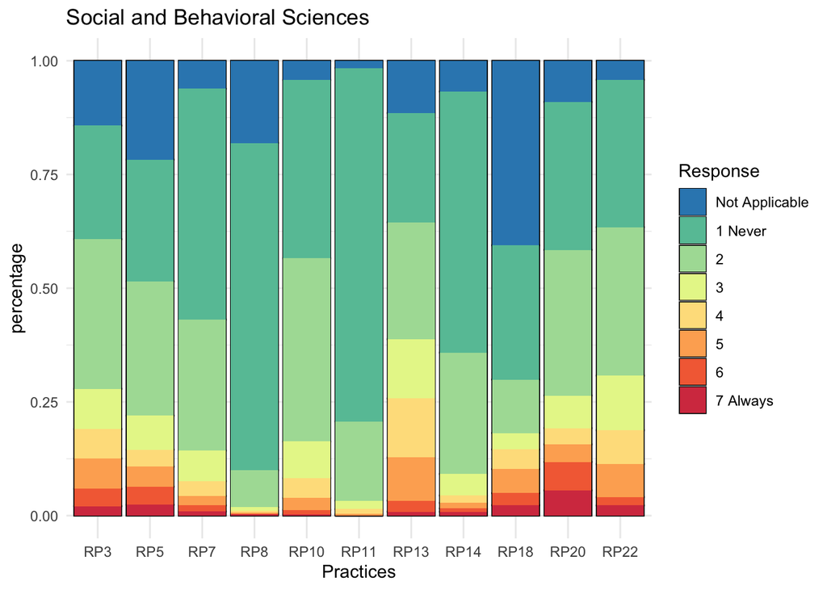

```
##
## $`Arts and Humanities`
```

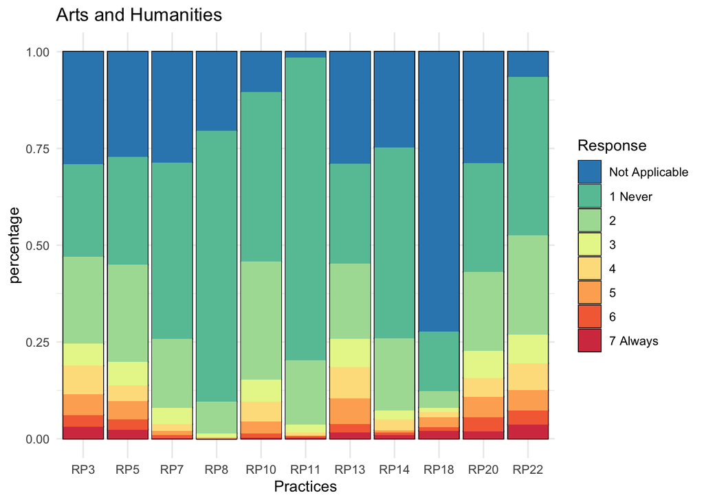

```
##
## $`Engineering and Natural Sciences`
```

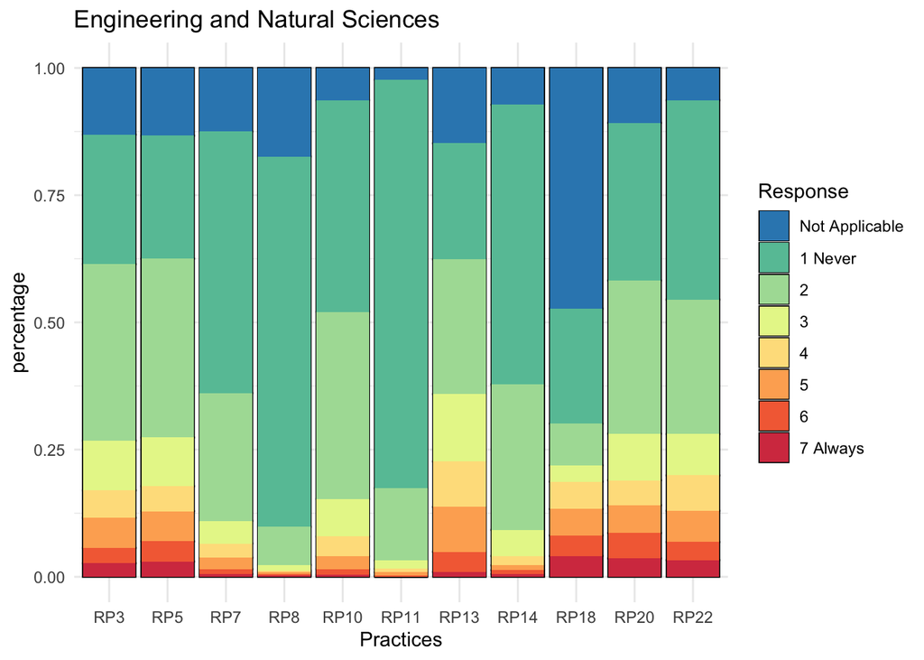

```
##
## $`Biomedical and Life Sciences`
```

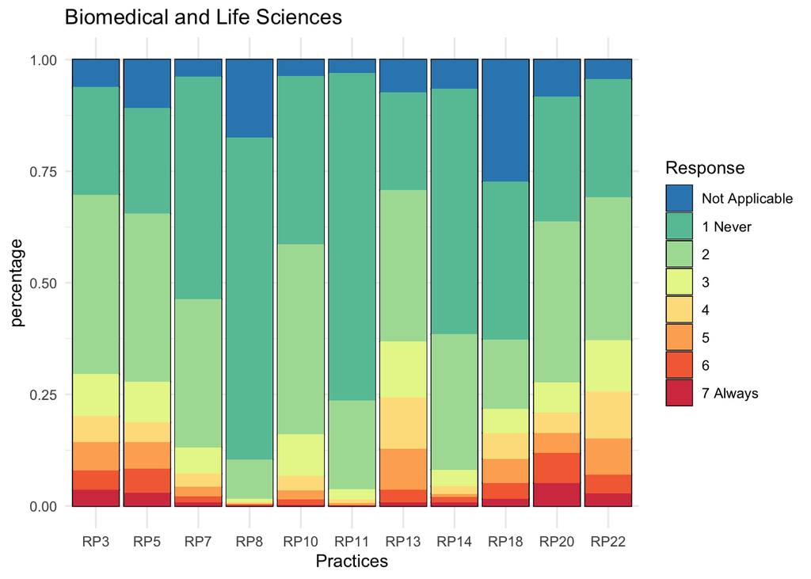

```r
barplotfun <- function(data){
  current <- sapply(out, function(x){identical(x, data)}) %>% which %>% names
  data %>%
    melt(varnames = c("Response", "Practices")) %>%
    mutate(Response = factor(Response),
           percentage = value / (sum(value)/11),
           Response = recode(Response, `0` = "Not Applicable", `1` = "1 Never", `7` = "7 Always")) %>%
    ggplot(aes(x = Practices, y = percentage, fill = Response)) +
    geom_bar(stat = 'identity', position = "stack", colour="black") +
    geom_col(position = position_stack(reverse = FALSE)) +
    scale_fill_brewer(palette = "Spectral", direction = -1) +
    theme_minimal() +
    ggtitle(current)
}
lapply(out, barplotfun)
```

### By academic rank

First, we grab the info from `D3`

```r
raw_data$D3 %>% var_label
```

```
## [1] "D3: Which academic rank do you belong to?"
```

```r
raw_data$D3 %>% val_labels
```

```
##                                                          PhD student or junior researcher
##                                                                                         1
## Postdoctoral researcher, Assistant Professor, Physician Researcher or Lecturer Researcher
##                                                                                         2
##                                                     Associate Professor or Full Professor
##                                                                                         3
##                                                                         None of the above
##                                                                                         4
```

Then we calculate a table for each of the labels in `D3`

```r
out <- mice::complete(imp, 1) %>%
  select(D3, all_of(QRP_set)) %>%
  mutate(across(where(is.numeric), as.factor)) %>%
  group_by(D3) %>%
  group_map(~sapply(., table, simplify = TRUE))
names(out) <- raw_data$D3 %>% val_labels %>% names %>% .[1:3]
out
```

```
## $`PhD student or junior researcher`
##   RP3 RP5 RP7 RP8 RP10 RP11 RP13 RP14 RP18 RP20 RP22
## 0 253 780 237 981  216  131  210  351 1025  411  234
## 1 412 445 775 891  633 1402  435  958  526  448  528
## 2 721 441 622 103  729  370  565  518  154  541  503
## 3 237 137 170  17  229   62  311  100   63  181  240
## 4 110  51 103   9   97   28  222   35   76   92  152
## 5 140  56  69   5   82   15  178   23   78  109  201
## 6  76  71  28   3   23    1   73   16   53  135   80
## 7  64  32   9   4    4    4   19   12   38   96   75
##
## $`Postdoctoral researcher, Assistant Professor, Physician Researcher or Lecturer Researcher`
##   RP3 RP5  RP7  RP8 RP10 RP11 RP13 RP14 RP18 RP20 RP22
## 0 303 275  210  216   72   17  287  126 1017  185   72
## 1 688 767 1402 2237 1109 2148  640 1558  774  814  885
```

[output cut: 17 more lines]

Then we calculate the proportional table

```r
p.out <- mice::complete(imp, 1) %>%
  select(D3, all_of(QRP_set)) %>%
  mutate(across(where(is.numeric), as.factor)) %>%
  group_by(D3) %>%
  group_map(~sapply(., p_tab, simplify = TRUE))
names(p.out) <- names(out)
p.out
```

```
## $`PhD student or junior researcher`
##     RP3   RP5   RP7   RP8  RP10  RP11  RP13  RP14  RP18  RP20  RP22
## 0 0.126 0.387 0.118 0.487 0.107 0.065 0.104 0.174 0.509 0.204 0.116
## 1 0.205 0.221 0.385 0.443 0.314 0.696 0.216 0.476 0.261 0.223 0.262
## 2 0.358 0.219 0.309 0.051 0.362 0.184 0.281 0.257 0.077 0.269 0.250
## 3 0.118 0.068 0.084 0.008 0.114 0.031 0.154 0.050 0.031 0.090 0.119
## 4 0.055 0.025 0.051 0.004 0.048 0.014 0.110 0.017 0.038 0.046 0.076
## 5 0.070 0.028 0.034 0.002 0.041 0.007 0.088 0.011 0.039 0.054 0.100
## 6 0.038 0.035 0.014 0.001 0.011 0.000 0.036 0.008 0.026 0.067 0.040
## 7 0.032 0.016 0.004 0.002 0.002 0.002 0.009 0.006 0.019 0.048 0.037
##
## $`Postdoctoral researcher, Assistant Professor, Physician Researcher or Lecturer Researcher`
##     RP3   RP5   RP7   RP8  RP10  RP11  RP13  RP14  RP18  RP20  RP22
## 0 0.111 0.101 0.077 0.079 0.026 0.006 0.105 0.046 0.372 0.068 0.026
## 1 0.252 0.281 0.513 0.819 0.406 0.786 0.234 0.570 0.283 0.298 0.324
```

[output cut: 17 more lines]

And the plots

```
## $`PhD student or junior researcher`
```

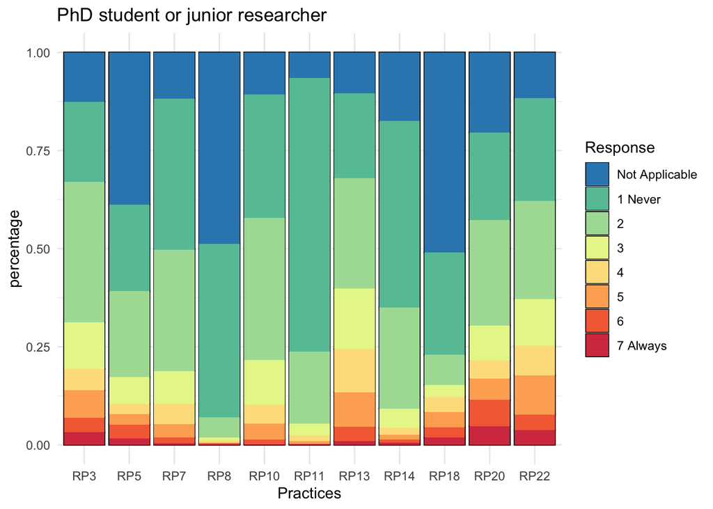

```
##
## $`Postdoctoral researcher, Assistant Professor, Physician Researcher or Lecturer Researcher`
```

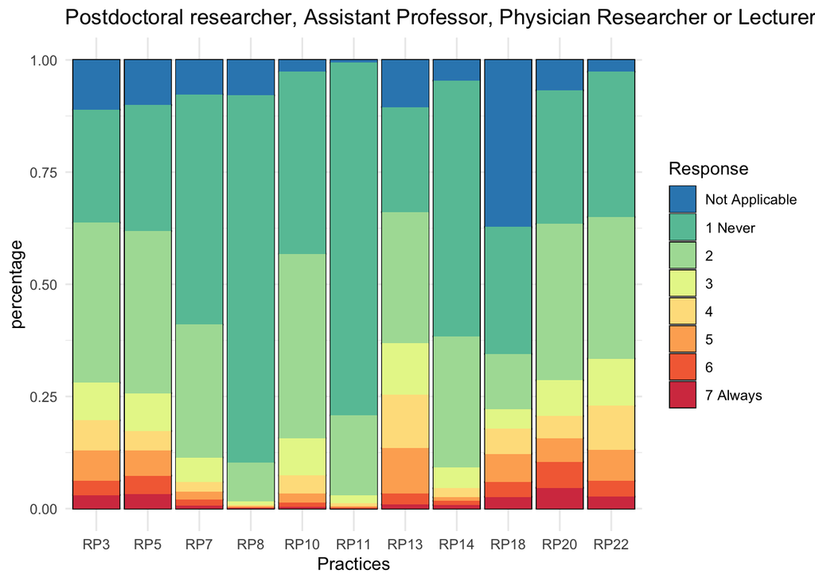

```
##
## $`Associate Professor or Full Professor`
```

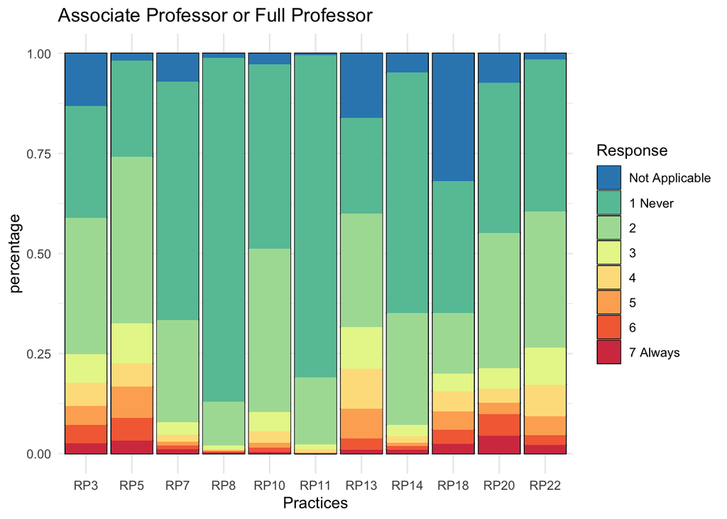

```r
lapply(out, barplotfun)
```

### By gender identification

First, we grab the info from `D4`

```r
raw_data$D4 %>% var_label
```

```
## [1] "D4: What is your gender?"
```

```r
raw_data$D4 %>% val_labels
```

```
##                          Female                            Male
##                               1                               2
## Other / Do not wish to disclose
##                               3
```

Then we calculate a table for each of the labels in `D4`

```r
out <- mice::complete(imp, 1) %>%
  select(D4, all_of(QRP_set)) %>%
  mutate(across(where(is.numeric), as.factor)) %>%
  group_by(D4) %>%
  group_map(~sapply(., table, simplify = TRUE))
names(out) <- raw_data$D4 %>% val_labels %>% names
out
```

```
## $Female
##    RP3 RP5  RP7  RP8 RP10 RP11 RP13 RP14 RP18 RP20 RP22
## 0  334 580  241  701  179   92  332  294 1246  375  172
## 1  696 826 1434 2049 1150 2184  701 1650  905  900  892
## 2 1097 944  906  206 1191  599  923  812  354  946  911
## 3  291 226  206   23  262   75  362  114  100  207  359
## 4  194 106   95   11  115   36  341   51  148  126  265
## 5  202 137   64    8   72   15  257   33  135  134  216
## 6  116 114   42    7   30    4   71   28   67  172  100
## 7   78  75   20    3    9    3   21   26   53  148   93
##
## $Male
##    RP3  RP5  RP7  RP8 RP10 RP11 RP13 RP14 RP18 RP20 RP22
## 0  472  489  331  499  157   65  476  271 1409  355  155
## 1  946  858 1919 2770 1491 2932  842 2040 1049 1104 1266
```

[output cut: 17 more lines]

Then we calculate the proportional table

```r
p.out <- mice::complete(imp, 1) %>%
  select(D4, all_of(QRP_set)) %>%
  mutate(across(where(is.numeric), as.factor)) %>%
  group_by(D4) %>%
  group_map(~sapply(., p_tab, simplify = TRUE))
names(p.out) <- names(out)
p.out
```

```
## $Female
##     RP3   RP5   RP7   RP8  RP10  RP11  RP13  RP14  RP18  RP20  RP22
## 0 0.111 0.193 0.080 0.233 0.060 0.031 0.110 0.098 0.414 0.125 0.057
## 1 0.231 0.275 0.477 0.681 0.382 0.726 0.233 0.549 0.301 0.299 0.297
## 2 0.365 0.314 0.301 0.068 0.396 0.199 0.307 0.270 0.118 0.314 0.303
## 3 0.097 0.075 0.068 0.008 0.087 0.025 0.120 0.038 0.033 0.069 0.119
## 4 0.064 0.035 0.032 0.004 0.038 0.012 0.113 0.017 0.049 0.042 0.088
## 5 0.067 0.046 0.021 0.003 0.024 0.005 0.085 0.011 0.045 0.045 0.072
## 6 0.039 0.038 0.014 0.002 0.010 0.001 0.024 0.009 0.022 0.057 0.033
## 7 0.026 0.025 0.007 0.001 0.003 0.001 0.007 0.009 0.018 0.049 0.031
##
## $Male
##     RP3   RP5   RP7   RP8  RP10  RP11  RP13  RP14  RP18  RP20  RP22
## 0 0.128 0.133 0.090 0.135 0.043 0.018 0.129 0.073 0.382 0.096 0.042
## 1 0.256 0.233 0.520 0.751 0.404 0.795 0.228 0.553 0.284 0.299 0.343
```

[output cut: 17 more lines]

And the plots

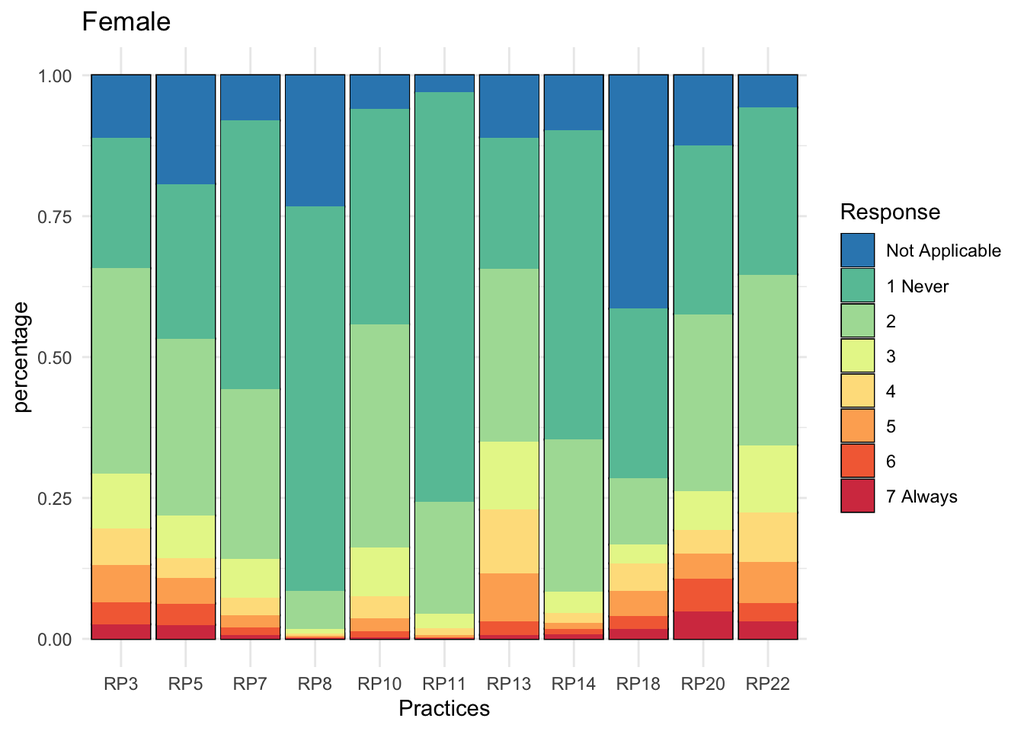

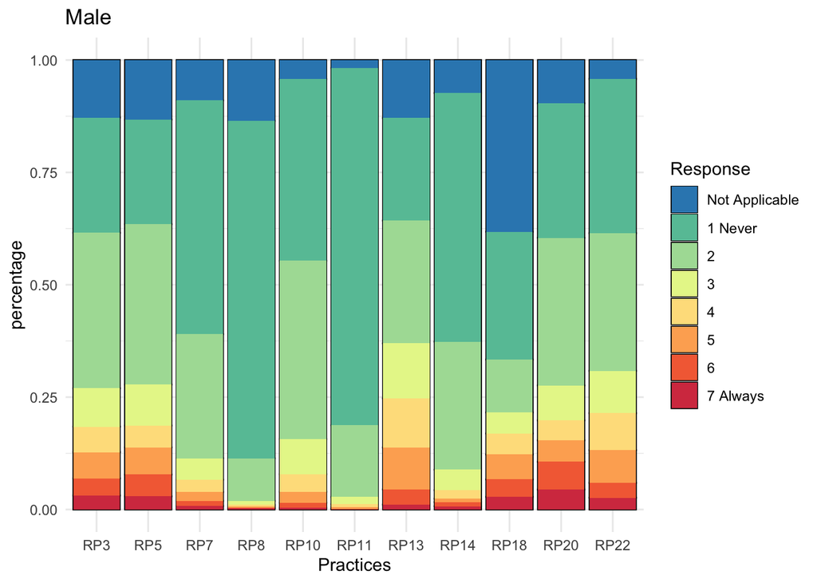

```
##
## $`Other / Do not wish to disclose`
```

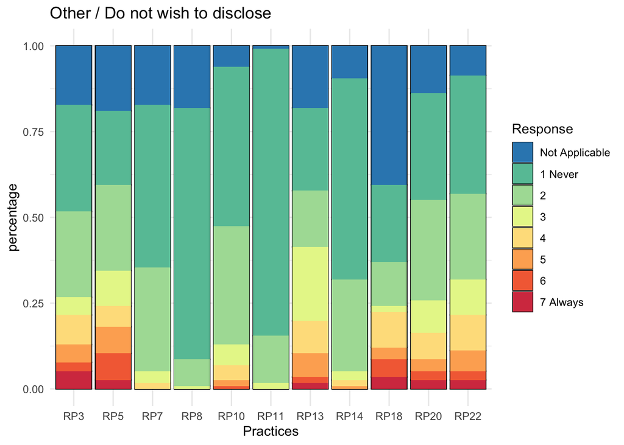

```r
lapply(out, barplotfun)
```

### By empirical research engagement

First, we grab the info from `D5`

```r
raw_data$D5 %>% var_label
```

```
## [1] "D5: Were you engaged in empirical research in the last three years?"
```

```r
raw_data$D5 %>% val_labels
```

```
## Yes  No
##   1   2
```

Then we calculate a table for each of the labels in `D5`

```r
out <- mice::complete(imp, 1) %>%
  select(D5, all_of(QRP_set)) %>%
  mutate(across(where(is.numeric), as.factor)) %>%
  group_by(D5) %>%
  group_map(~sapply(., table, simplify = TRUE))
names(out) <- raw_data$D5 %>% val_labels %>% names
out
```

```
## $Yes
##    RP3  RP5  RP7  RP8 RP10 RP11 RP13 RP14 RP18 RP20 RP22
## 0  574  893  318 1042  222  128  584  381 2215  530  249
## 1 1527 1523 3124 4443 2403 4666 1390 3437 1871 1865 1923
## 2 2232 2106 1840  493 2494 1084 1819 1743  764 2021 1898
## 3  562  529  361   48  503  116  781  247  264  443  670
## 4  374  258  185   18  236   51  713  107  309  273  529
## 5  389  335  129   15  138   27  563   60  327  277  441
## 6  245  278   80   12   67    6  177   58  191  375  204
## 7  180  161   46   12   20    5   56   50  142  299  169
##
## $No
##   RP3 RP5 RP7 RP8 RP10 RP11 RP13 RP14 RP18 RP20 RP22
## 0 252 198 274 179  121   30  245  195  487  216   88
## 1 151 186 284 461  292  547  181  321  109  175  275
## 2 170 183 119  72  200  120  130  151   39  171  172
## 3  50  46  25   7   54   20   58   38   11   61   48
## 4  39  34  13   5   28    9   42   16   23   26   52
## 5  35  34   8   6   26    2   46    2   17   37   50
## 6  14  24   4   0    6    2   21    4   25   28   21
## 7  19  25   3   0    3    0    7    3   19   16   24
```

Then we calculate the proportional table

```r
p.out <- mice::complete(imp, 1) %>%
  select(D5, all_of(QRP_set)) %>%
  mutate(across(where(is.numeric), as.factor)) %>%
  group_by(D5) %>%
  group_map(~sapply(., p_tab, simplify = TRUE))
names(p.out) <- names(out)
p.out
```

```
## $Yes
##     RP3   RP5   RP7   RP8  RP10  RP11  RP13  RP14  RP18  RP20  RP22
## 0 0.094 0.147 0.052 0.171 0.036 0.021 0.096 0.063 0.364 0.087 0.041
## 1 0.251 0.250 0.514 0.730 0.395 0.767 0.229 0.565 0.308 0.307 0.316
## 2 0.367 0.346 0.302 0.081 0.410 0.178 0.299 0.287 0.126 0.332 0.312
## 3 0.092 0.087 0.059 0.008 0.083 0.019 0.128 0.041 0.043 0.073 0.110
## 4 0.061 0.042 0.030 0.003 0.039 0.008 0.117 0.018 0.051 0.045 0.087
## 5 0.064 0.055 0.021 0.002 0.023 0.004 0.093 0.010 0.054 0.046 0.072
## 6 0.040 0.046 0.013 0.002 0.011 0.001 0.029 0.010 0.031 0.062 0.034
## 7 0.030 0.026 0.008 0.002 0.003 0.001 0.009 0.008 0.023 0.049 0.028
##
## $No
##     RP3   RP5   RP7   RP8  RP10  RP11  RP13  RP14  RP18  RP20  RP22
## 0 0.345 0.271 0.375 0.245 0.166 0.041 0.336 0.267 0.667 0.296 0.121
## 1 0.207 0.255 0.389 0.632 0.400 0.749 0.248 0.440 0.149 0.240 0.377
## 2 0.233 0.251 0.163 0.099 0.274 0.164 0.178 0.207 0.053 0.234 0.236
## 3 0.068 0.063 0.034 0.010 0.074 0.027 0.079 0.052 0.015 0.084 0.066
## 4 0.053 0.047 0.018 0.007 0.038 0.012 0.058 0.022 0.032 0.036 0.071
## 5 0.048 0.047 0.011 0.008 0.036 0.003 0.063 0.003 0.023 0.051 0.068
## 6 0.019 0.033 0.005 0.000 0.008 0.003 0.029 0.005 0.034 0.038 0.029
## 7 0.026 0.034 0.004 0.000 0.004 0.000 0.010 0.004 0.026 0.022 0.033
```

And the plots

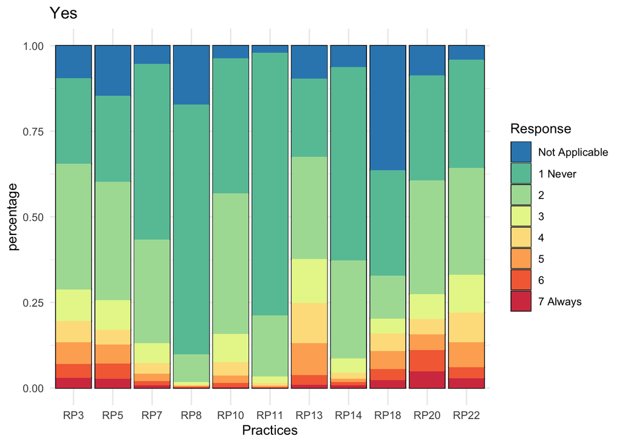

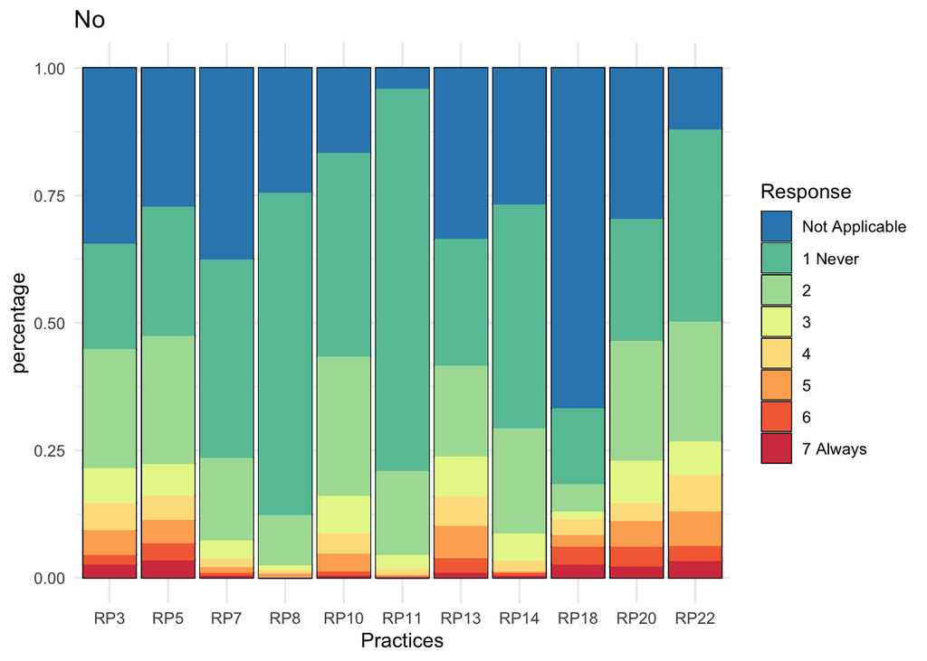

```r
lapply(out, barplotfun)
```

### By institutional support

First, we grab the info from `Group`

```r
raw_data$Group %>% var_label
```

```
## [1] "Group"
```

```r
raw_data$Group %>% val_labels
```

```
##     Joining group Non-joining group
##                 1                 2
```

Then we calculate a table for each of the labels in `Group`

```r
out <- mice::complete(imp, 1) %>%
  select(Group, all_of(QRP_set)) %>%
  mutate(across(where(is.numeric), as.factor)) %>%
  group_by(Group) %>%
  group_map(~sapply(., table, simplify = TRUE))
names(out) <- raw_data$Group %>% val_labels %>% names
out
```

```
## $`Joining group`
##    RP3  RP5  RP7  RP8 RP10 RP11 RP13 RP14 RP18 RP20 RP22
## 0  387  616  289  709  179   98  379  323 1300  389  183
## 1  779  822 1574 2240 1254 2450  720 1804 1002  913  980
## 2 1195 1061  981  261 1310  601  978  891  381 1088 1017
## 3  296  249  189   29  288   72  424  117  115  235  352
## 4  202  127  102   13  114   34  361   51  140  152  294
## 5  196  162   70    8   85   10  301   31  165  133  261
## 6  126  146   42    3   27    3   78   30   99  198   99
## 7   89   87   23    7   13    2   29   23   68  162   84
##
## $`Non-joining group`
##    RP3  RP5  RP7  RP8 RP10 RP11 RP13 RP14 RP18 RP20 RP22
## 0  439  475  303  512  164   60  450  253 1402  357  154
## 1  899  887 1834 2664 1441 2763  851 1954  978 1127 1218
## 2 1207 1228  978  304 1384  603  971 1003  422 1104 1053
## 3  316  326  197   26  269   64  415  168  160  269  366
## 4  211  165   96   10  150   26  394   72  192  147  287
## 5  228  207   67   13   79   19  308   31  179  181  230
## 6  133  156   42    9   46    5  120   32  117  205  126
## 7  110   99   26    5   10    3   34   30   93  153  109
```

Then we calculate the proportional table

```r
p.out <- mice::complete(imp, 1) %>%
  select(Group, all_of(QRP_set)) %>%
  mutate(across(where(is.numeric), as.factor)) %>%
  group_by(Group) %>%
  group_map(~sapply(., p_tab, simplify = TRUE))
names(p.out) <- names(out)
p.out
```

```
## $`Joining group`
##     RP3   RP5   RP7   RP8  RP10  RP11  RP13  RP14  RP18  RP20  RP22
## 0 0.118 0.188 0.088 0.217 0.055 0.030 0.116 0.099 0.398 0.119 0.056
## 1 0.238 0.251 0.481 0.685 0.383 0.749 0.220 0.552 0.306 0.279 0.300
## 2 0.365 0.324 0.300 0.080 0.401 0.184 0.299 0.272 0.117 0.333 0.311
## 3 0.091 0.076 0.058 0.009 0.088 0.022 0.130 0.036 0.035 0.072 0.108
## 4 0.062 0.039 0.031 0.004 0.035 0.010 0.110 0.016 0.043 0.046 0.090
## 5 0.060 0.050 0.021 0.002 0.026 0.003 0.092 0.009 0.050 0.041 0.080
## 6 0.039 0.045 0.013 0.001 0.008 0.001 0.024 0.009 0.030 0.061 0.030
## 7 0.027 0.027 0.007 0.002 0.004 0.001 0.009 0.007 0.021 0.050 0.026
##
## $`Non-joining group`
##     RP3   RP5   RP7   RP8  RP10  RP11  RP13  RP14  RP18  RP20  RP22
## 0 0.124 0.134 0.086 0.145 0.046 0.017 0.127 0.071 0.396 0.101 0.043
## 1 0.254 0.250 0.518 0.752 0.407 0.780 0.240 0.552 0.276 0.318 0.344
## 2 0.341 0.347 0.276 0.086 0.391 0.170 0.274 0.283 0.119 0.312 0.297
## 3 0.089 0.092 0.056 0.007 0.076 0.018 0.117 0.047 0.045 0.076 0.103
## 4 0.060 0.047 0.027 0.003 0.042 0.007 0.111 0.020 0.054 0.041 0.081
## 5 0.064 0.058 0.019 0.004 0.022 0.005 0.087 0.009 0.051 0.051 0.065
## 6 0.038 0.044 0.012 0.003 0.013 0.001 0.034 0.009 0.033 0.058 0.036
## 7 0.031 0.028 0.007 0.001 0.003 0.001 0.010 0.008 0.026 0.043 0.031
```

And the plots

```
## $`Joining group`
```

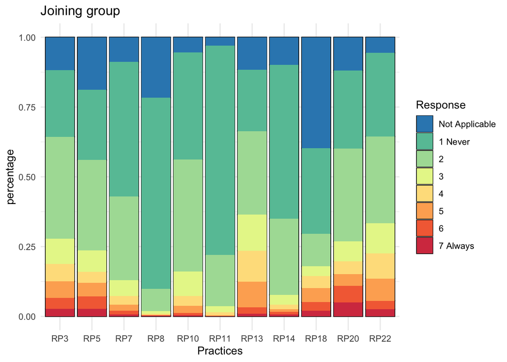

```
##
## $`Non-joining group`
```

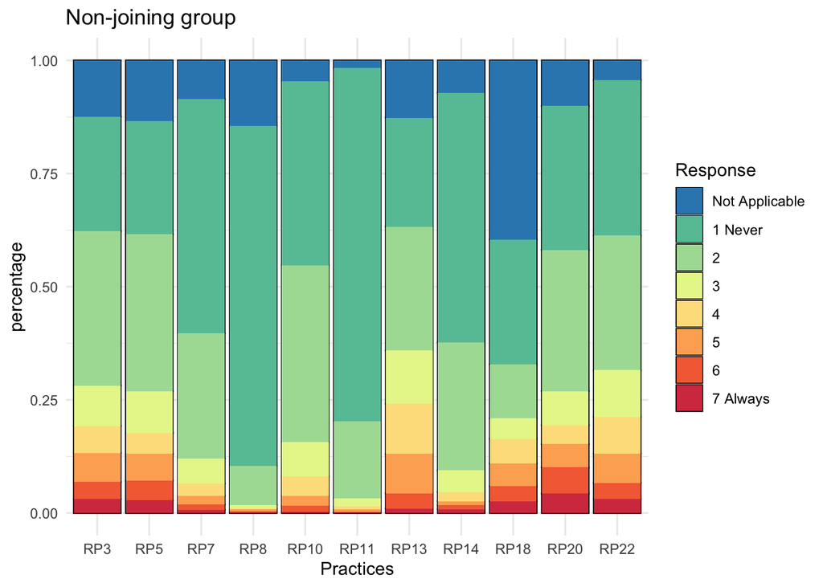

```r
lapply(out, barplotfun)
```

# QRP without `Not Applicable`’s

## Tables and plots

### Overall

```r
mice::complete(imp, 1) %>% #QRP has no missings -so use 1st imputed set
  select(all_of(QRP_set)) %>%
  na_if(0) %>%
  sapply(table)
```

```
##    RP3  RP5  RP7  RP8 RP10 RP11 RP13 RP14 RP18 RP20 RP22
## 1 1678 1709 3408 4904 2695 5213 1571 3758 1980 2040 2198
## 2 2402 2289 1959  565 2694 1204 1949 1894  803 2192 2070
## 3  612  575  386   55  557  136  839  285  275  504  718
## 4  413  292  198   23  264   60  755  123  332  299  581
## 5  424  369  137   21  164   29  609   62  344  314  491
## 6  259  302   84   12   73    8  198   62  216  403  225
## 7  199  186   49   12   23    5   63   53  161  315  193
```

Zero indicates not applicable

Then we calculate the proportional table

```r
p_tab <- function(x){prop.table(table(x)) %>% round(3)}
mice::complete(imp, 1) %>% #QRP has no missings -so use 1st imputed set
  select(all_of(QRP_set)) %>%
  na_if(0) %>%
  sapply(p_tab) %>%
  round(3)
```

```
##     RP3   RP5   RP7   RP8  RP10  RP11  RP13  RP14  RP18  RP20  RP22
## 1 0.280 0.299 0.548 0.877 0.417 0.783 0.263 0.603 0.482 0.336 0.339
## 2 0.401 0.400 0.315 0.101 0.416 0.181 0.326 0.304 0.195 0.361 0.320
## 3 0.102 0.100 0.062 0.010 0.086 0.020 0.140 0.046 0.067 0.083 0.111
## 4 0.069 0.051 0.032 0.004 0.041 0.009 0.126 0.020 0.081 0.049 0.090
## 5 0.071 0.064 0.022 0.004 0.025 0.004 0.102 0.010 0.084 0.052 0.076
## 6 0.043 0.053 0.014 0.002 0.011 0.001 0.033 0.010 0.053 0.066 0.035
## 7 0.033 0.033 0.008 0.002 0.004 0.001 0.011 0.008 0.039 0.052 0.030
```

Next, we create the stacked barplot.

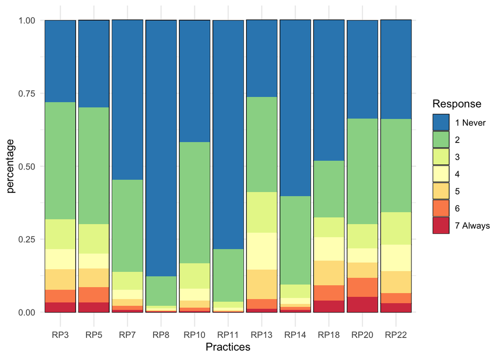

```r
mice::complete(imp, 1) %>% #QRP has no missings -so use 1st imputed set
  select(all_of(QRP_set)) %>%
  na_if(0) %>%
  sapply(p_tab) %>%
  melt(varnames = c("Response", "Practices")) %>%
  mutate(Response = factor(Response),
         percentage = value,
         Response = recode(Response, `1` = "1 Never", `7` = "7 Always")) %>%
  ggplot(aes(x = Practices, y = percentage, fill = Response)) +
  geom_bar(stat = 'identity', position = "stack", colour="black") +
  geom_col(position = position_stack(reverse = FALSE)) +
  scale_fill_brewer(palette = "Spectral", direction = -1) +
  theme_minimal()
```

### By Disciplinary Field

First, we grab the info from `D2`

```r
raw_data$D2 %>% var_label
```

```
## [1] "D2: Which of the following is your main disciplinary field of research?"
```

```r
raw_data$D2 %>% val_labels
```

```
##   Social and Behavioral Sciences              Arts and Humanities
##                                1                                2
## Engineering and Natural Sciences     Biomedical and Life Sciences
##                                3                                4
```

Then we calculate a table for each of the labels in `D2`

```r
out <- mice::complete(imp, 1) %>%
  select(D2, all_of(QRP_set)) %>%
  na_if(0) %>%
  mutate(across(where(is.numeric), as.factor)) %>%
  group_by(D2) %>%
  group_map(~sapply(., table, simplify = TRUE))
names(out) <- raw_data$D2 %>% val_labels %>% names
out
```

```
## $`Social and Behavioral Sciences`
##   RP3 RP5 RP7  RP8 RP10 RP11 RP13 RP14 RP18 RP20 RP22
## 1 491 526 997 1414  770 1527  472 1128  580  639  637
## 2 646 580 566  160  792  342  505  524  231  629  641
## 3 174 147 132   14  158   37  256   93   71  141  236
## 4 127  73  64    8   86   21  255   32   85   70  146
## 5 131  87  41    7   51    6  186   24  104   76  143
## 6  75  78  26    1   19    1   48   14   52  123   36
## 7  41  47  18    6    6    0   17   17   45  109   44
##
## $`Arts and Humanities`
##   RP3 RP5 RP7 RP8 RP10 RP11 RP13 RP14 RP18 RP20 RP22
## 1 152 177 290 445  279  497  164  314   98  179  261
## 2 143 160 113  52  194  106  124  119   27  130  163
## 3  36  38  27   6   36   13   46   14    7   44   47
```

[output cut: 24 more lines]

Then we calculate the proportional table

```r
p.out <- mice::complete(imp, 1) %>%
  select(D2, all_of(QRP_set)) %>%
  na_if(0) %>%
  mutate(across(where(is.numeric), as.factor)) %>%
  group_by(D2) %>%
  group_map(~sapply(., p_tab, simplify = TRUE))
names(p.out) <- names(out)
p.out
```

```
## $`Social and Behavioral Sciences`
##     RP3   RP5   RP7   RP8  RP10  RP11  RP13  RP14  RP18  RP20  RP22
## 1 0.291 0.342 0.541 0.878 0.409 0.790 0.271 0.616 0.497 0.358 0.338
## 2 0.383 0.377 0.307 0.099 0.421 0.177 0.290 0.286 0.198 0.352 0.340
## 3 0.103 0.096 0.072 0.009 0.084 0.019 0.147 0.051 0.061 0.079 0.125
## 4 0.075 0.047 0.035 0.005 0.046 0.011 0.147 0.017 0.073 0.039 0.078
## 5 0.078 0.057 0.022 0.004 0.027 0.003 0.107 0.013 0.089 0.043 0.076
## 6 0.045 0.051 0.014 0.001 0.010 0.001 0.028 0.008 0.045 0.069 0.019
## 7 0.024 0.031 0.010 0.004 0.003 0.000 0.010 0.009 0.039 0.061 0.023
##
## $`Arts and Humanities`
##     RP3   RP5   RP7   RP8  RP10  RP11  RP13  RP14  RP18  RP20  RP22
## 1 0.337 0.382 0.639 0.879 0.489 0.794 0.363 0.656 0.557 0.395 0.439
## 2 0.317 0.346 0.249 0.103 0.340 0.169 0.274 0.248 0.153 0.287 0.274
## 3 0.080 0.082 0.059 0.012 0.063 0.021 0.102 0.029 0.040 0.097 0.079
```

[output cut: 24 more lines]

And the plots

```
## $`Social and Behavioral Sciences`
```

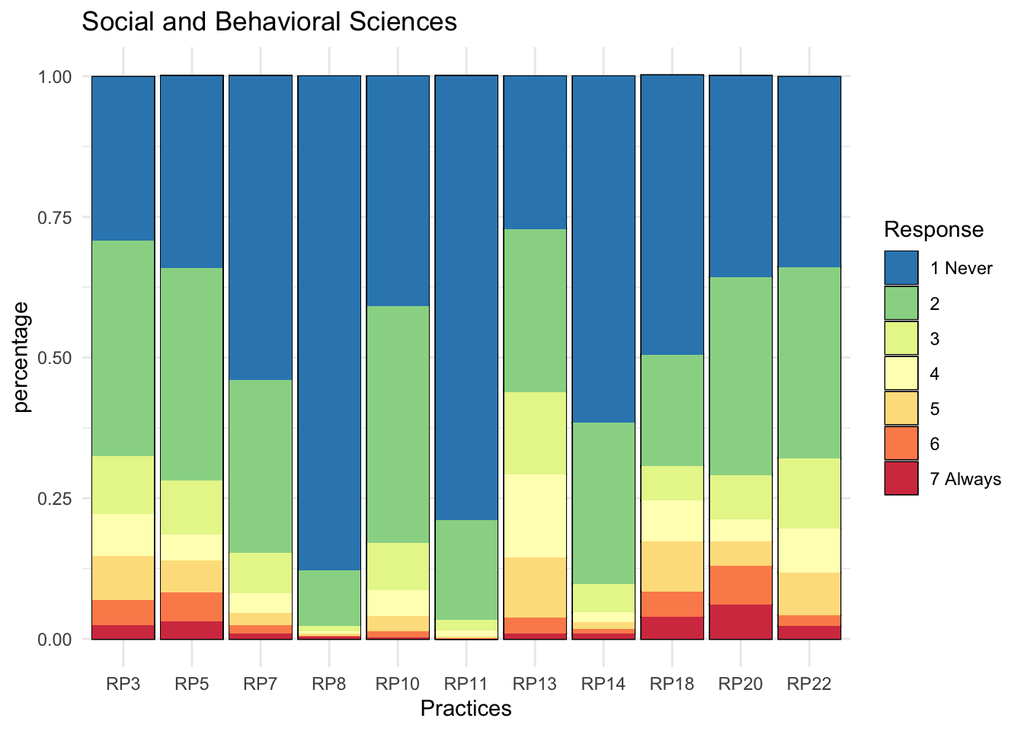

```
##
## $`Arts and Humanities`
```

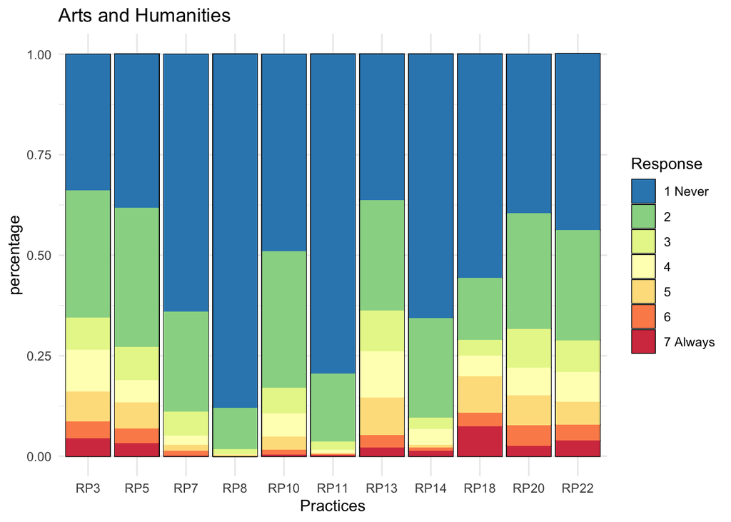

```
##
## $`Engineering and Natural Sciences`
```

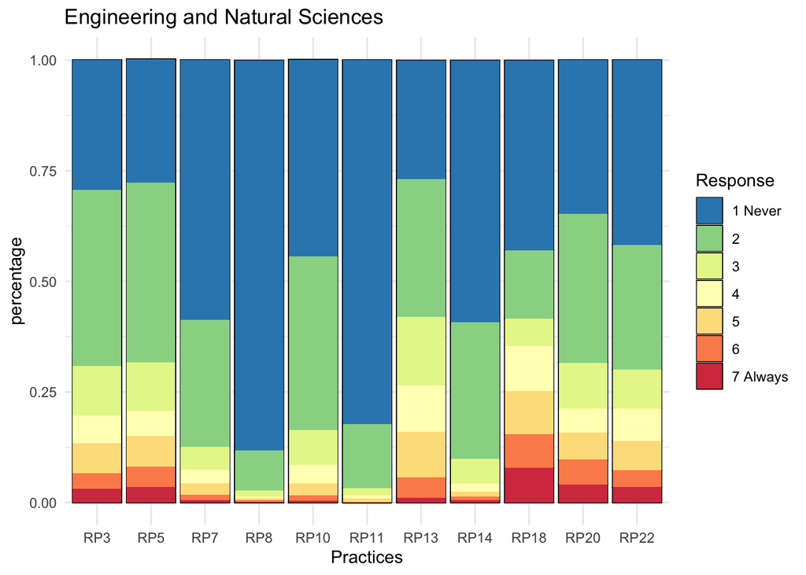

```
##
## $`Biomedical and Life Sciences`
```

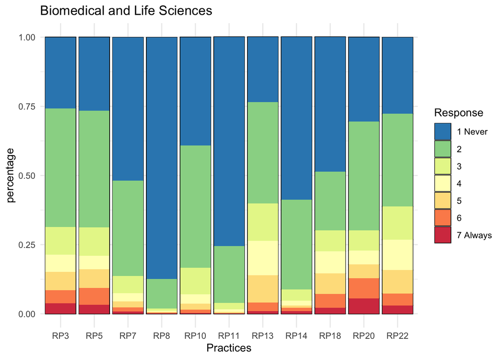

```r
barplotfun <- function(data){
  current <- sapply(p.out, function(x){identical(x, data)}) %>% which %>% names
  data %>%
    melt(varnames = c("Response", "Practices")) %>%
    mutate(Response = factor(Response),
           percentage = value / (sum(value)/11),
           Response = recode(Response, `1` = "1 Never", `7` = "7 Always")) %>%
    ggplot(aes(x = Practices, y = percentage, fill = Response)) +
    geom_bar(stat = 'identity', position = "stack", colour="black") +
    geom_col(position = position_stack(reverse = FALSE)) +
    scale_fill_brewer(palette = "Spectral", direction = -1) +
    theme_minimal() +
    ggtitle(current)
}
lapply(p.out, barplotfun)
```

### By academic rank

First, we grab the info from `D3`

```r
raw_data$D3 %>% var_label
```

```
## [1] "D3: Which academic rank do you belong to?"
```

```r
raw_data$D3 %>% val_labels
```

```
##                                                          PhD student or junior researcher
##                                                                                         1
## Postdoctoral researcher, Assistant Professor, Physician Researcher or Lecturer Researcher
##                                                                                         2
##                                                     Associate Professor or Full Professor
##                                                                                         3
##                                                                         None of the above
##                                                                                         4
```

Then we calculate a table for each of the labels in `D3`

```r
out <- mice::complete(imp, 1) %>%
  select(D3, all_of(QRP_set)) %>%
  na_if(0) %>%
  mutate(across(where(is.numeric), as.factor)) %>%
  group_by(D3) %>%
  group_map(~sapply(., table, simplify = TRUE))
names(out) <- raw_data$D3 %>% val_labels %>% names %>% .[1:3]
out
```

```
## $`PhD student or junior researcher`
##   RP3 RP5 RP7 RP8 RP10 RP11 RP13 RP14 RP18 RP20 RP22
## 1 412 445 775 891  633 1402  435  958  526  448  528
## 2 721 441 622 103  729  370  565  518  154  541  503
## 3 237 137 170  17  229   62  311  100   63  181  240
## 4 110  51 103   9   97   28  222   35   76   92  152
## 5 140  56  69   5   82   15  178   23   78  109  201
## 6  76  71  28   3   23    1   73   16   53  135   80
## 7  64  32   9   4    4    4   19   12   38   96   75
##
## $`Postdoctoral researcher, Assistant Professor, Physician Researcher or Lecturer Researcher`
##   RP3 RP5  RP7  RP8 RP10 RP11 RP13 RP14 RP18 RP20 RP22
## 1 688 767 1402 2237 1109 2148  640 1558  774  814  885
## 2 975 988  809  237 1122  488  799  798  336  952  863
## 3 229 230  150   19  227   47  313  127  120  218  287
## 4 183 120   60    9  109   17  326   55  152  134  267
## 5 185 152   47    9   57   10  277   22  172  146  190
## 6  87 114   36    4   27    5   66   25   90  157   96
## 7  83  87   19    2   10    1   25   22   72  127   73
##
## $`Associate Professor or Full Professor`
##   RP3 RP5  RP7  RP8 RP10 RP11 RP13 RP14 RP18 RP20 RP22
## 1 578 497 1231 1776  953 1663  496 1242  680  778  785
## 2 706 860  528  225  843  346  585  578  313  699  704
## 3 146 208   66   19  101   27  215   58   92  105  191
## 4 120 121   35    5   58   15  207   33  104   73  162
## 5  99 161   21    7   25    4  154   17   94   59  100
## 6  96 117   20    5   23    2   59   21   73  111   49
## 7  52  67   21    6    9    0   19   19   51   92   45
```

Then we calculate the proportional table

```r
p.out <- mice::complete(imp, 1) %>%
  select(D3, all_of(QRP_set)) %>%
  na_if(0) %>%
  mutate(across(where(is.numeric), as.factor)) %>%
  group_by(D3) %>%
  group_map(~sapply(., p_tab, simplify = TRUE))
names(p.out) <- names(out)
p.out
```

```
## $`PhD student or junior researcher`
##     RP3   RP5   RP7   RP8  RP10  RP11  RP13  RP14  RP18  RP20  RP22
## 1 0.234 0.361 0.436 0.863 0.352 0.745 0.241 0.576 0.532 0.280 0.297
## 2 0.410 0.358 0.350 0.100 0.406 0.197 0.313 0.312 0.156 0.338 0.283
## 3 0.135 0.111 0.096 0.016 0.127 0.033 0.172 0.060 0.064 0.113 0.135
## 4 0.062 0.041 0.058 0.009 0.054 0.015 0.123 0.021 0.077 0.057 0.085
## 5 0.080 0.045 0.039 0.005 0.046 0.008 0.099 0.014 0.079 0.068 0.113
## 6 0.043 0.058 0.016 0.003 0.013 0.001 0.040 0.010 0.054 0.084 0.045
## 7 0.036 0.026 0.005 0.004 0.002 0.002 0.011 0.007 0.038 0.060 0.042
##
## $`Postdoctoral researcher, Assistant Professor, Physician Researcher or Lecturer Researcher`
##     RP3   RP5   RP7   RP8  RP10  RP11  RP13  RP14  RP18  RP20  RP22
## 1 0.283 0.312 0.556 0.889 0.417 0.791 0.262 0.598 0.451 0.319 0.333
## 2 0.401 0.402 0.321 0.094 0.422 0.180 0.327 0.306 0.196 0.374 0.324
## 3 0.094 0.094 0.059 0.008 0.085 0.017 0.128 0.049 0.070 0.086 0.108
## 4 0.075 0.049 0.024 0.004 0.041 0.006 0.133 0.021 0.089 0.053 0.100
## 5 0.076 0.062 0.019 0.004 0.021 0.004 0.113 0.008 0.100 0.057 0.071
## 6 0.036 0.046 0.014 0.002 0.010 0.002 0.027 0.010 0.052 0.062 0.036
## 7 0.034 0.035 0.008 0.001 0.004 0.000 0.010 0.008 0.042 0.050 0.027
##
## $`Associate Professor or Full Professor`
##     RP3   RP5   RP7   RP8  RP10  RP11  RP13  RP14  RP18  RP20  RP22
## 1 0.322 0.245 0.640 0.869 0.474 0.808 0.286 0.631 0.483 0.406 0.386
## 2 0.393 0.423 0.275 0.110 0.419 0.168 0.337 0.294 0.222 0.365 0.346
## 3 0.081 0.102 0.034 0.009 0.050 0.013 0.124 0.029 0.065 0.055 0.094
## 4 0.067 0.060 0.018 0.002 0.029 0.007 0.119 0.017 0.074 0.038 0.080
## 5 0.055 0.079 0.011 0.003 0.012 0.002 0.089 0.009 0.067 0.031 0.049
## 6 0.053 0.058 0.010 0.002 0.011 0.001 0.034 0.011 0.052 0.058 0.024
## 7 0.029 0.033 0.011 0.003 0.004 0.000 0.011 0.010 0.036 0.048 0.022
```

And the plots

```
## $`PhD student or junior researcher`
```

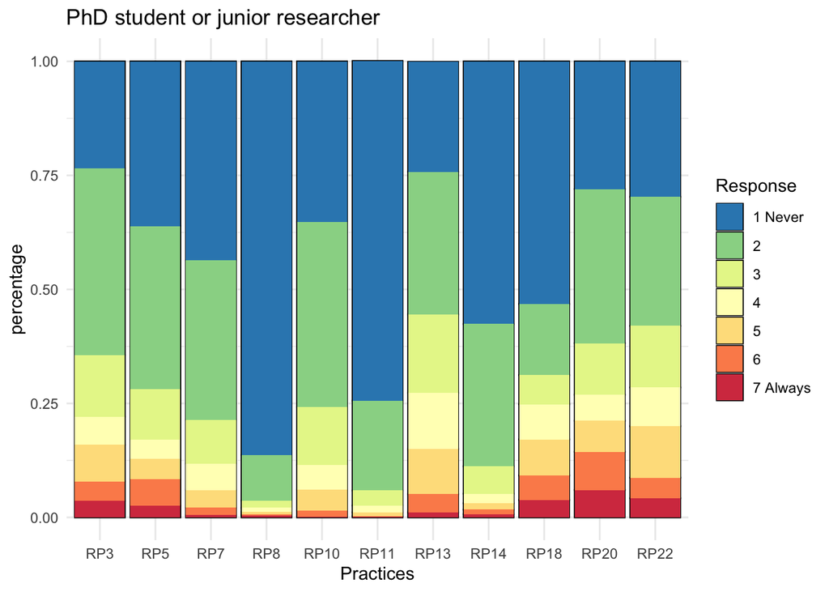

```
##
## $`Postdoctoral researcher, Assistant Professor, Physician Researcher or Lecturer Researcher`
```

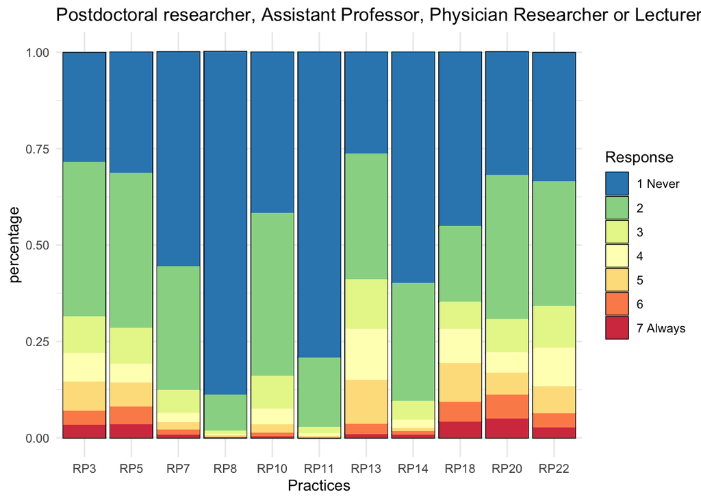

```
##
## $`Associate Professor or Full Professor`
```

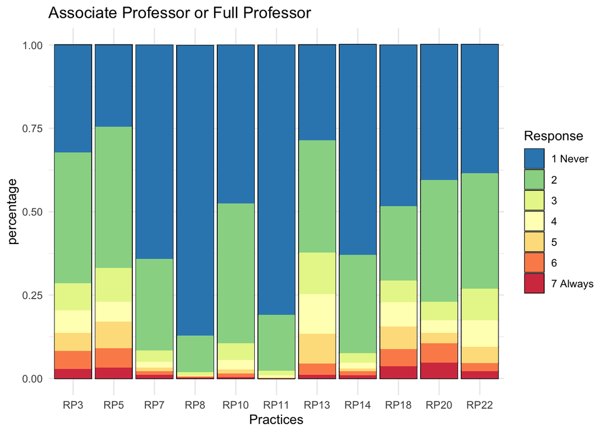

```r
lapply(p.out, barplotfun)
```

### By gender identification

First, we grab the info from `D4`

```r
raw_data$D4 %>% var_label
```

```
## [1] "D4: What is your gender?"
```

```r
raw_data$D4 %>% val_labels
```

```
##                          Female                            Male
##                               1                               2
## Other / Do not wish to disclose
##                               3
```

Then we calculate a table for each of the labels in `D4`

```r
out <- mice::complete(imp, 1) %>%
  select(D4, all_of(QRP_set)) %>%
  na_if(0) %>%
  mutate(across(where(is.numeric), as.factor)) %>%
  group_by(D4) %>%
  group_map(~sapply(., table, simplify = TRUE))
names(out) <- raw_data$D4 %>% val_labels %>% names
out
```

```
## $Female
##    RP3 RP5  RP7  RP8 RP10 RP11 RP13 RP14 RP18 RP20 RP22
## 1  696 826 1434 2049 1150 2184  701 1650  905  900  892
## 2 1097 944  906  206 1191  599  923  812  354  946  911
## 3  291 226  206   23  262   75  362  114  100  207  359
## 4  194 106   95   11  115   36  341   51  148  126  265
## 5  202 137   64    8   72   15  257   33  135  134  216
## 6  116 114   42    7   30    4   71   28   67  172  100
## 7   78  75   20    3    9    3   21   26   53  148   93
##
## $Male
##    RP3  RP5  RP7  RP8 RP10 RP11 RP13 RP14 RP18 RP20 RP22
## 1  946  858 1919 2770 1491 2932  842 2040 1049 1104 1266
## 2 1276 1316 1018  350 1463  589 1007 1051  434 1212 1130
## 3  315  337  176   31  288   59  452  168  173  286  347
## 4  209  179  101   12  144   24  403   70  172  164  304
## 5  216  223   73   13   90   14  344   28  205  176  268
## 6  140  179   42    5   42    4  125   34  143  228  122
## 7  115  108   29    9   14    2   40   27  104  164   97
##
## $`Other / Do not wish to disclose`
##   RP3 RP5 RP7 RP8 RP10 RP11 RP13 RP14 RP18 RP20 RP22
## 1  36  25  55  85   54   97   28   68   26   36   40
## 2  29  29  35   9   40   16   19   31   15   34   29
## 3   6  12   4   1    7    2   25    3    2   11   12
## 4  10   7   2   0    5    0   11    2   12    9   12
## 5   6   9   0   0    2    0    8    1    4    4    7
## 6   3   9   0   0    1    0    2    0    6    3    3
## 7   6   3   0   0    0    0    2    0    4    3    3
```

Then we calculate the proportional table

```r
p.out <- mice::complete(imp, 1) %>%
  select(D4, all_of(QRP_set)) %>%
  na_if(0) %>%
  mutate(across(where(is.numeric), as.factor)) %>%
  group_by(D4) %>%
  group_map(~sapply(., p_tab, simplify = TRUE))
names(p.out) <- names(out)
p.out
```

```
## $Female
##     RP3   RP5   RP7   RP8  RP10  RP11  RP13  RP14  RP18  RP20  RP22
## 1 0.260 0.340 0.518 0.888 0.407 0.749 0.262 0.608 0.514 0.342 0.315
## 2 0.410 0.389 0.327 0.089 0.421 0.205 0.345 0.299 0.201 0.359 0.321
## 3 0.109 0.093 0.074 0.010 0.093 0.026 0.135 0.042 0.057 0.079 0.127
## 4 0.073 0.044 0.034 0.005 0.041 0.012 0.127 0.019 0.084 0.048 0.093
## 5 0.076 0.056 0.023 0.003 0.025 0.005 0.096 0.012 0.077 0.051 0.076
## 6 0.043 0.047 0.015 0.003 0.011 0.001 0.027 0.010 0.038 0.065 0.035
## 7 0.029 0.031 0.007 0.001 0.003 0.001 0.008 0.010 0.030 0.056 0.033
##
## $Male
##     RP3   RP5   RP7   RP8  RP10  RP11  RP13  RP14  RP18  RP20  RP22
## 1 0.294 0.268 0.571 0.868 0.422 0.809 0.262 0.597 0.460 0.331 0.358
## 2 0.397 0.411 0.303 0.110 0.414 0.163 0.313 0.307 0.190 0.364 0.320
## 3 0.098 0.105 0.052 0.010 0.082 0.016 0.141 0.049 0.076 0.086 0.098
## 4 0.065 0.056 0.030 0.004 0.041 0.007 0.125 0.020 0.075 0.049 0.086
## 5 0.067 0.070 0.022 0.004 0.025 0.004 0.107 0.008 0.090 0.053 0.076
## 6 0.044 0.056 0.013 0.002 0.012 0.001 0.039 0.010 0.063 0.068 0.035
## 7 0.036 0.034 0.009 0.003 0.004 0.001 0.012 0.008 0.046 0.049 0.027
##
## $`Other / Do not wish to disclose`
##     RP3   RP5   RP7   RP8  RP10  RP11  RP13  RP14  RP18 RP20  RP22
## 1 0.375 0.266 0.573 0.895 0.495 0.843 0.295 0.648 0.377 0.36 0.377
## 2 0.302 0.309 0.365 0.095 0.367 0.139 0.200 0.295 0.217 0.34 0.274
## 3 0.062 0.128 0.042 0.011 0.064 0.017 0.263 0.029 0.029 0.11 0.113
## 4 0.104 0.074 0.021 0.000 0.046 0.000 0.116 0.019 0.174 0.09 0.113
## 5 0.062 0.096 0.000 0.000 0.018 0.000 0.084 0.010 0.058 0.04 0.066
## 6 0.031 0.096 0.000 0.000 0.009 0.000 0.021 0.000 0.087 0.03 0.028
## 7 0.062 0.032 0.000 0.000 0.000 0.000 0.021 0.000 0.058 0.03 0.028
```

And the plots

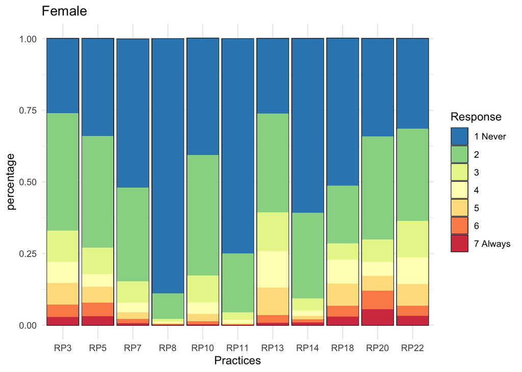

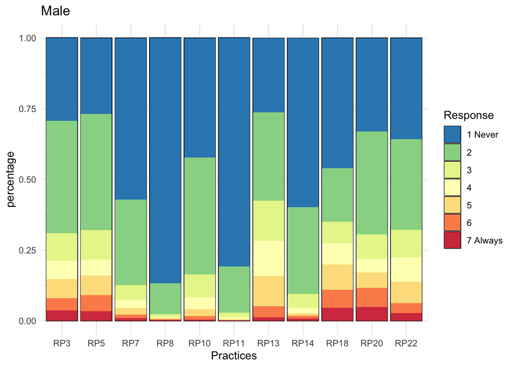

```
##
## $`Other / Do not wish to disclose`
```

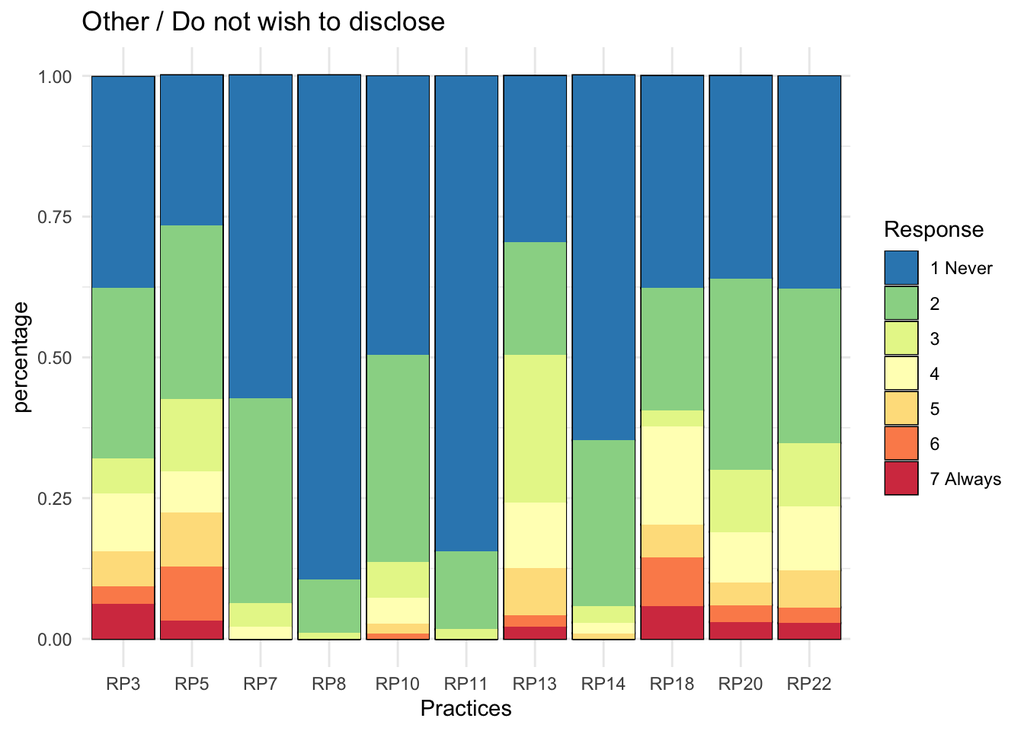

```r
lapply(p.out, barplotfun)
```

### By empirical research engagement

First, we grab the info from `D5`

```r
raw_data$D5 %>% var_label
```

```
## [1] "D5: Were you engaged in empirical research in the last three years?"
```

```r
raw_data$D5 %>% val_labels
```

```
## Yes  No
##   1   2
```

Then we calculate a table for each of the labels in `D5`

```r
out <- mice::complete(imp, 1) %>%
  select(D5, all_of(QRP_set)) %>%
  na_if(0) %>%
  mutate(across(where(is.numeric), as.factor)) %>%
  group_by(D5) %>%
  group_map(~sapply(., table, simplify = TRUE))
names(out) <- raw_data$D5 %>% val_labels %>% names
out
```

```
## $Yes
##    RP3  RP5  RP7  RP8 RP10 RP11 RP13 RP14 RP18 RP20 RP22
## 1 1527 1523 3124 4443 2403 4666 1390 3437 1871 1865 1923
## 2 2232 2106 1840  493 2494 1084 1819 1743  764 2021 1898
## 3  562  529  361   48  503  116  781  247  264  443  670
## 4  374  258  185   18  236   51  713  107  309  273  529
## 5  389  335  129   15  138   27  563   60  327  277  441
## 6  245  278   80   12   67    6  177   58  191  375  204
## 7  180  161   46   12   20    5   56   50  142  299  169
##
## $No
##   RP3 RP5 RP7 RP8 RP10 RP11 RP13 RP14 RP18 RP20 RP22
## 1 151 186 284 461  292  547  181  321  109  175  275
## 2 170 183 119  72  200  120  130  151   39  171  172
## 3  50  46  25   7   54   20   58   38   11   61   48
## 4  39  34  13   5   28    9   42   16   23   26   52
## 5  35  34   8   6   26    2   46    2   17   37   50
## 6  14  24   4   0    6    2   21    4   25   28   21
## 7  19  25   3   0    3    0    7    3   19   16   24
```

Then we calculate the proportional table

```r
p.out <- mice::complete(imp, 1) %>%
  select(D5, all_of(QRP_set)) %>%
  na_if(0) %>%
  mutate(across(where(is.numeric), as.factor)) %>%
  group_by(D5) %>%
  group_map(~sapply(., p_tab, simplify = TRUE))
names(p.out) <- names(out)
p.out
```

```
## $Yes
##     RP3   RP5   RP7   RP8  RP10  RP11  RP13  RP14  RP18  RP20  RP22
## 1 0.277 0.293 0.542 0.881 0.410 0.784 0.253 0.603 0.484 0.336 0.330
## 2 0.405 0.406 0.319 0.098 0.426 0.182 0.331 0.306 0.198 0.364 0.325
## 3 0.102 0.102 0.063 0.010 0.086 0.019 0.142 0.043 0.068 0.080 0.115
## 4 0.068 0.050 0.032 0.004 0.040 0.009 0.130 0.019 0.080 0.049 0.091
## 5 0.071 0.065 0.022 0.003 0.024 0.005 0.102 0.011 0.085 0.050 0.076
## 6 0.044 0.054 0.014 0.002 0.011 0.001 0.032 0.010 0.049 0.068 0.035
## 7 0.033 0.031 0.008 0.002 0.003 0.001 0.010 0.009 0.037 0.054 0.029
##
## $No
##     RP3   RP5   RP7   RP8  RP10  RP11  RP13  RP14  RP18  RP20  RP22
## 1 0.316 0.350 0.623 0.837 0.479 0.781 0.373 0.600 0.449 0.340 0.428
## 2 0.356 0.344 0.261 0.131 0.328 0.171 0.268 0.282 0.160 0.333 0.268
## 3 0.105 0.086 0.055 0.013 0.089 0.029 0.120 0.071 0.045 0.119 0.075
## 4 0.082 0.064 0.029 0.009 0.046 0.013 0.087 0.030 0.095 0.051 0.081
## 5 0.073 0.064 0.018 0.011 0.043 0.003 0.095 0.004 0.070 0.072 0.078
## 6 0.029 0.045 0.009 0.000 0.010 0.003 0.043 0.007 0.103 0.054 0.033
## 7 0.040 0.047 0.007 0.000 0.005 0.000 0.014 0.006 0.078 0.031 0.037
```

And the plots

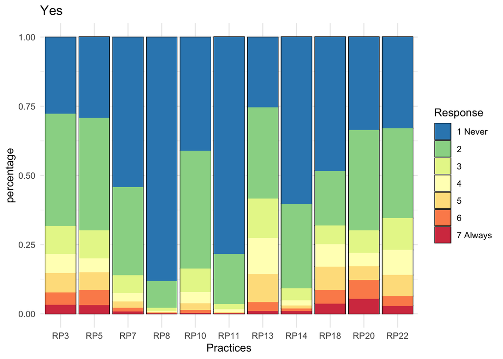

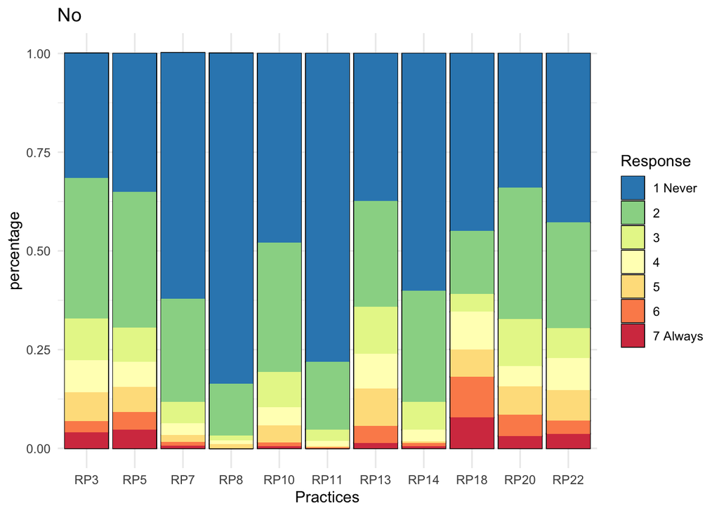

```r
lapply(p.out, barplotfun)
```

### By institutional support

First, we grab the info from `Group`

```r
raw_data$Group %>% var_label
```

```
## [1] "Group"
```

```r
raw_data$Group %>% val_labels
```

```
##     Joining group Non-joining group
##                 1                 2
```

Then we calculate a table for each of the labels in `Group`

```r
out <- mice::complete(imp, 1) %>%
  select(Group, all_of(QRP_set)) %>%
  na_if(0) %>%
  mutate(across(where(is.numeric), as.factor)) %>%
  group_by(Group) %>%
  group_map(~sapply(., table, simplify = TRUE))
names(out) <- raw_data$Group %>% val_labels %>% names
out
```

```
## $`Joining group`
##    RP3  RP5  RP7  RP8 RP10 RP11 RP13 RP14 RP18 RP20 RP22
## 1  779  822 1574 2240 1254 2450  720 1804 1002  913  980
## 2 1195 1061  981  261 1310  601  978  891  381 1088 1017
## 3  296  249  189   29  288   72  424  117  115  235  352
## 4  202  127  102   13  114   34  361   51  140  152  294
## 5  196  162   70    8   85   10  301   31  165  133  261
## 6  126  146   42    3   27    3   78   30   99  198   99
## 7   89   87   23    7   13    2   29   23   68  162   84
##
## $`Non-joining group`
##    RP3  RP5  RP7  RP8 RP10 RP11 RP13 RP14 RP18 RP20 RP22
## 1  899  887 1834 2664 1441 2763  851 1954  978 1127 1218
## 2 1207 1228  978  304 1384  603  971 1003  422 1104 1053
## 3  316  326  197   26  269   64  415  168  160  269  366
## 4  211  165   96   10  150   26  394   72  192  147  287
## 5  228  207   67   13   79   19  308   31  179  181  230
## 6  133  156   42    9   46    5  120   32  117  205  126
## 7  110   99   26    5   10    3   34   30   93  153  109
```

Then we calculate the proportional table

```r
p.out <- mice::complete(imp, 1) %>%
  select(Group, all_of(QRP_set)) %>%
  na_if(0) %>%
  mutate(across(where(is.numeric), as.factor)) %>%
  group_by(Group) %>%
  group_map(~sapply(., p_tab, simplify = TRUE))
names(p.out) <- names(out)
p.out
```

```
## $`Joining group`
##     RP3   RP5   RP7   RP8  RP10  RP11  RP13  RP14  RP18  RP20  RP22
## 1 0.270 0.310 0.528 0.875 0.406 0.772 0.249 0.612 0.509 0.317 0.317
## 2 0.414 0.400 0.329 0.102 0.424 0.189 0.338 0.302 0.193 0.378 0.329
## 3 0.103 0.094 0.063 0.011 0.093 0.023 0.147 0.040 0.058 0.082 0.114
## 4 0.070 0.048 0.034 0.005 0.037 0.011 0.125 0.017 0.071 0.053 0.095
## 5 0.068 0.061 0.023 0.003 0.027 0.003 0.104 0.011 0.084 0.046 0.085
## 6 0.044 0.055 0.014 0.001 0.009 0.001 0.027 0.010 0.050 0.069 0.032
## 7 0.031 0.033 0.008 0.003 0.004 0.001 0.010 0.008 0.035 0.056 0.027
##
## $`Non-joining group`
##     RP3   RP5   RP7   RP8  RP10  RP11  RP13  RP14  RP18  RP20  RP22
## 1 0.290 0.289 0.566 0.879 0.426 0.793 0.275 0.594 0.457 0.354 0.359
## 2 0.389 0.400 0.302 0.100 0.410 0.173 0.314 0.305 0.197 0.347 0.311
## 3 0.102 0.106 0.061 0.009 0.080 0.018 0.134 0.051 0.075 0.084 0.108
## 4 0.068 0.054 0.030 0.003 0.044 0.007 0.127 0.022 0.090 0.046 0.085
## 5 0.073 0.067 0.021 0.004 0.023 0.005 0.100 0.009 0.084 0.057 0.068
## 6 0.043 0.051 0.013 0.003 0.014 0.001 0.039 0.010 0.055 0.064 0.037
## 7 0.035 0.032 0.008 0.002 0.003 0.001 0.011 0.009 0.043 0.048 0.032
```

And the plots

```
## $`Joining group`
```

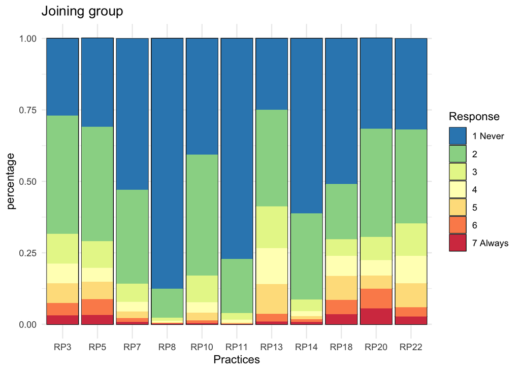

```
##
## $`Non-joining group`
```

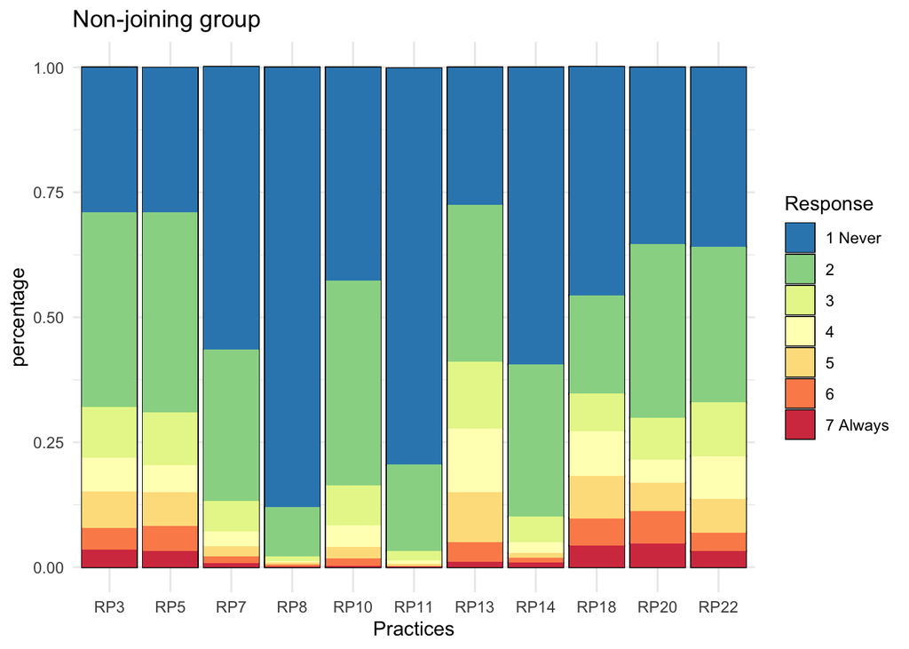

```r
lapply(p.out, barplotfun)
```

# Document info

Signed: [Gerko Vink](https://www.gerkovink.com),

```r
timestamp()
```

```
## ##------ Tue Apr  6 20:37:42 2021 ------##
```

END of DOCUMENT